# Model_Review

Brooklynn McNeil

2025-03-25

# Loading Data and Exploratory Data Analysis

When building models it is important to start with tidy data, removing any columns that won’t be used as predictors (i.e “ID”). Make sure that categorical variables are read in as factors.

## Upload Data (still need a relative path for this)

```r
load("./dat1.RData")
load("./dat2.RData")
```

## Specify Training and Testing Sets

When building a model we must partition the data into two sets: training and testing. All of the model building procedures will be done based on the training dataset including parameter optimization and model selection. Only the final model will be tested using the testing dataset to evaluate the performance and generalizability of the model. Generally, a data split will occur with 80% of the original data in the training set and the other 20% in the testing dataset.

```r
train_df = dat1 |> select(-id)
test_df = dat2 |> select(-id)
```

The data above has already been split, but we can use the caret package??? to create our partition.Always set a seed when doing this to control the randomness. Use this same seed for training all of the models.

```r
set.seed(56)
#using dat 1 as example data as if it is the only data we obtained

#datSplit = initial_split(data = dat1, prop = 0.8)
#trainData = training(datSplit)
#testData = testing(datSplit)
```

## Exploratory Data Analysis

Check the distribution of the response variable. For linear regression this needs to be normally distributed. Explore transformations such as log if it is not normally distributed. If using a generalized linear model the response variable doesn’t necessarily need to be normally distributed.

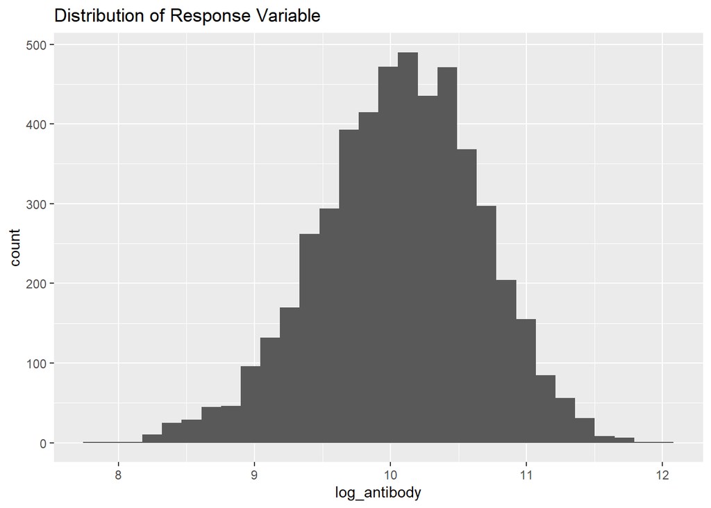

```r
train_df |>
  ggplot(aes(x = log_antibody)) +
  geom_histogram() +
  ggtitle("Distribution of Response Variable")
```

Check if there are any highly correlated predictors included. If there are, these should be watched throughout the model building processed and make sure only the most significant are removed.

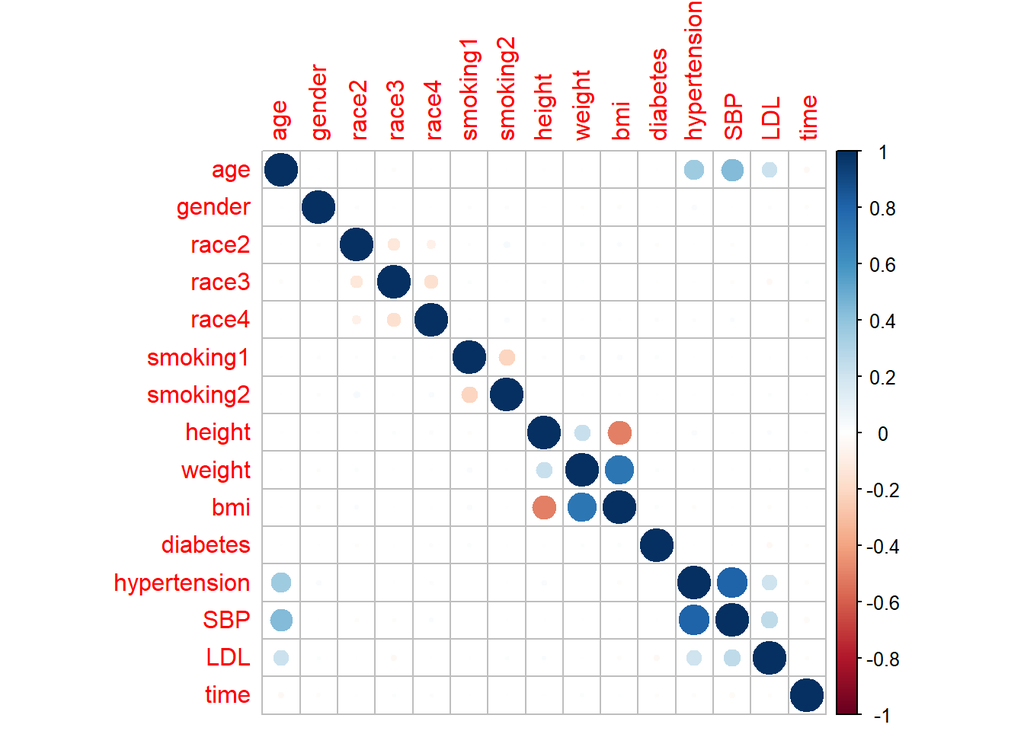

```r
# matrix of predictors
x = model.matrix(log_antibody ~ ., train_df) [,-1]

# correlation plot
corrplot(cor(x), method = "circle", type = "full")
```

# Model Building Process

Using the caret package, we can use the basic formula below, and change the `method` and some parameters for the type of model that we want to build. For this part we will use the simple linear model built using Ordinary Least Squares (OLS).

## Cross Validation

Before we actually start building the model we need to make sure we are doing cross validation. Use the `trainControl` function from caret to set up how we do cross validation.Below we set up a cross validation parameter with k=10 folds.

```r
# k-fold cv
ctrl1 = trainControl(method = "cv", number = 10)

# if you want to use the 1se rule
ctrl_1se = trainControl(method = "1se", number = 10)

# leave-one-out CV
ctrl_2 = trainControl(method = "LOOCV")

# leave-group-out / Monte Carlo CV
ctrl_3 = trainControl(method = "LGOCV", p = 0.75, number = 50)

# bootstrap
ctrl_4 = trainControl(method = "boot632", number = 100)

# repeated K-fold CV
ctrl_5 = trainControl(method = "repeatedcv", repeats = 5, number = 10)

# only fit one model to the entire training set
ctrl_6 = trainControl(method = "none")
```

## Train the Model

Train the model using caret’s `train` function and the `ctrl1` training parameters. For OLS use method “lm”.

```r
set.seed(56)
lm_fit = train(log_antibody ~ .,
               data = train_df,
               method = "lm",
               trControl = ctrl1)

# get the coefficients
summary(lm_fit)
```

```
##
## Call:
## lm(formula = .outcome ~ ., data = dat)
##
## Residuals:
##      Min       1Q   Median       3Q      Max
## -2.14396 -0.35840  0.02944  0.37802  1.65090
##
## Coefficients:
##                Estimate Std. Error t value Pr(>|t|)
## (Intercept)  26.6751961  2.3149812  11.523  < 2e-16 ***
## age          -0.0205979  0.0019385 -10.626  < 2e-16 ***
## gender       -0.2974929  0.0155977 -19.073  < 2e-16 ***
## race2        -0.0060422  0.0344613  -0.175   0.8608
## race3        -0.0075295  0.0196815  -0.383   0.7021
## race4        -0.0417571  0.0273309  -1.528   0.1266
## smoking1      0.0219907  0.0173992   1.264   0.2063
## smoking2     -0.1934834  0.0269576  -7.177 8.15e-13 ***
## height       -0.0821381  0.0135622  -6.056 1.49e-09 ***
## weight        0.0859034  0.0143481   5.987 2.29e-09 ***
## bmi          -0.2977935  0.0412612  -7.217 6.10e-13 ***
## diabetes      0.0112795  0.0215643   0.523   0.6010
## hypertension -0.0179106  0.0260931  -0.686   0.4925
## SBP           0.0015181  0.0017049   0.890   0.3733
## LDL          -0.0001645  0.0004028  -0.409   0.6829
## time         -0.0003011  0.0001795  -1.677   0.0936 .
## ---
## Signif. codes:  0 '***' 0.001 '**' 0.01 '*' 0.05 '.' 0.1 ' ' 1
##
## Residual standard error: 0.5503 on 4984 degrees of freedom
## Multiple R-squared:  0.1513, Adjusted R-squared:  0.1488
## F-statistic: 59.25 on 15 and 4984 DF,  p-value: < 2.2e-16
```

Get the prediction error using predictions from the model and the actual response value from the test data. Take the mean squared error “MSE” to report the test error.

```r
MSPE_lm_pred = predict(lm_fit, newdata = test_df)

MSPE_lm = mean((MSPE_lm_pred - test_df$log_antibody)^2)
MSPE_lm
```

```
## [1] 0.3229854
```

# Linear Models with Regularization

### Ridge Model

Ridge models have type 1 pentaly terms that will shrink the coefficients of highly correlated predictors, but not eliminate them from the model. To build a ridge model we set alpha to 0 and create a grid for lambda values that determine how large the penalty term can be.

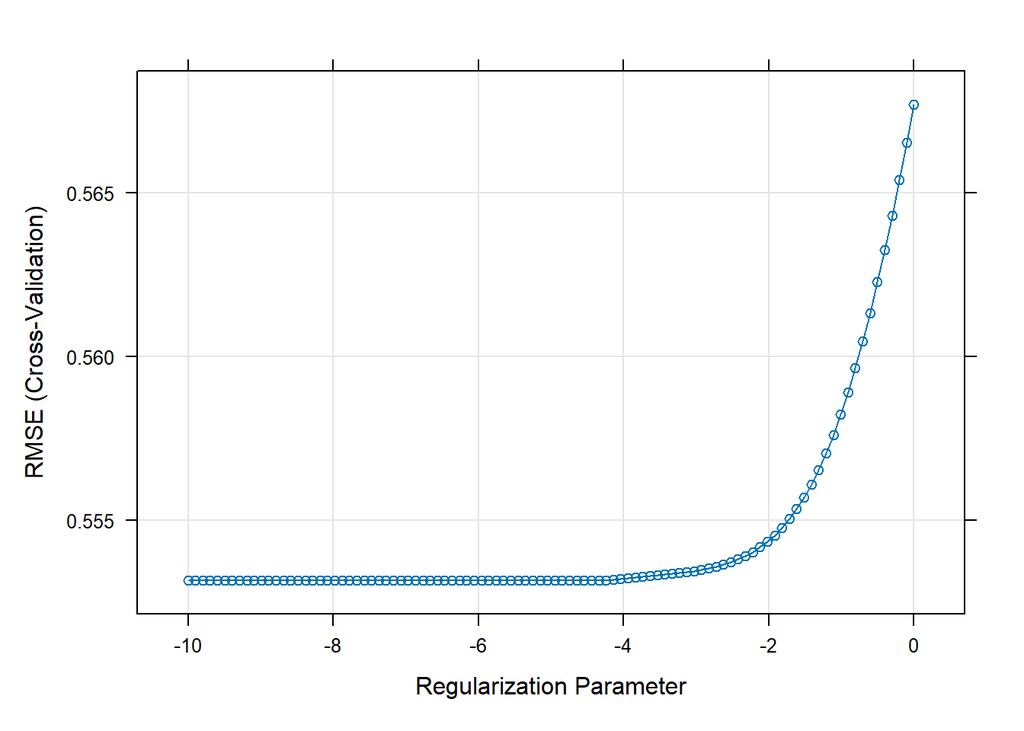

```r
set.seed(56)
ridge_fit = train(log_antibody ~ .,
               data = train_df,
               method = "glmnet",
               trControl = ctrl1,
               tuneGrid = expand.grid(alpha = 0, # for ridge specifically
                                      lambda = exp(seq(-10,0, length = 100)))) # create gride for 100 different lambda values between -10, 0

# find the lambda value with lowest RMSE
plot(ridge_fit, xTrans = log)
```

```r
ridge_fit$bestTune$lambda
```

```
## [1] 0.01299183
```

### Lasso Model

```r
set.seed(56)
lasso_fit = train(log_antibody ~ .,
               data = train_df,
               method = "glmnet",
               trControl = ctrl1,
               tuneGrid = expand.grid(alpha = 1, # for Lasso specifically
                                      lambda = exp(seq(-10,0, length = 100)))) # create gride for 100 different lambda values between -10, 0
```

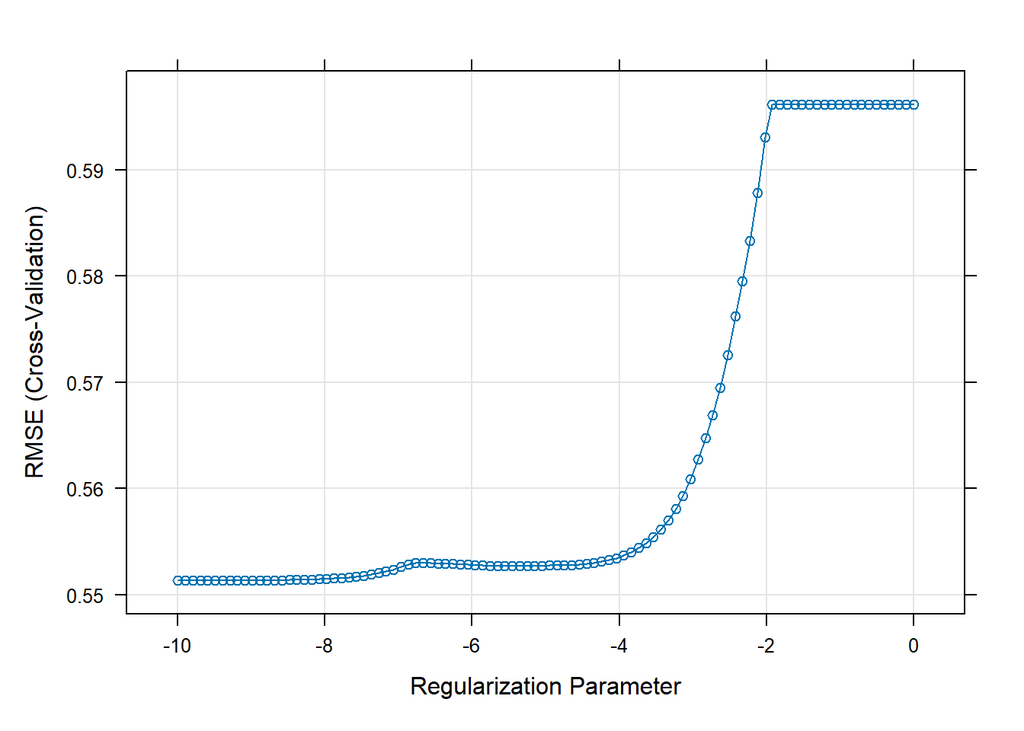

```r
# find the lambda value with lowest RMSE
plot(lasso_fit, xTrans = log)
```

```r
lasso_fit$bestTune$lambda
```

```
## [1] 4.539993e-05
```

### Elastic Net

Elastic Net models use a mixture of lasso and ridge penalty terms. We create a grid of alpha values to determine the best mixture of models.

```r
set.seed(56)
enet_fit = train(log_antibody ~ .,
               data = train_df,
               method = "glmnet",
               trControl = ctrl1,
               tuneGrid = expand.grid(alpha = seq(0,1, length = 21), # create a model for each alpha value with 0.5 spacing
                                      lambda = exp(seq(-10,0, length = 100)))) # create gride for 100 different lambda values between -10, 0
```

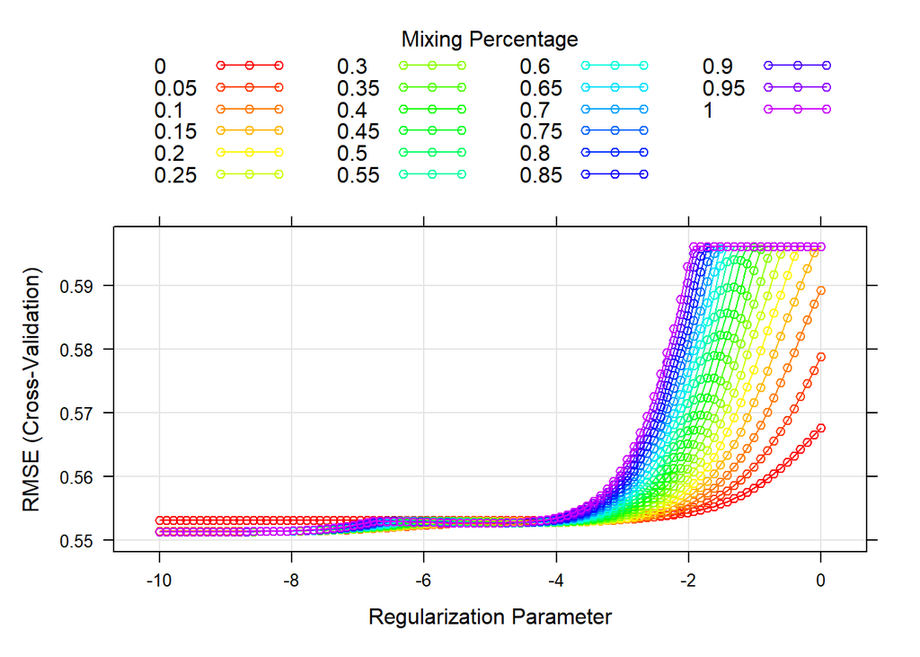

```r
# find the lambda value with lowest RMSE
myCol = rainbow(25)
myPar = list(superpose.symbol = list(col = myCol),
             superpose.line = list(col = myCol))

plot(enet_fit, par.settings = myPar, xTrans = log)
```

```r
enet_fit$bestTune$lambda
```

```
## [1] 4.539993e-05
```

# Comparing Different Models

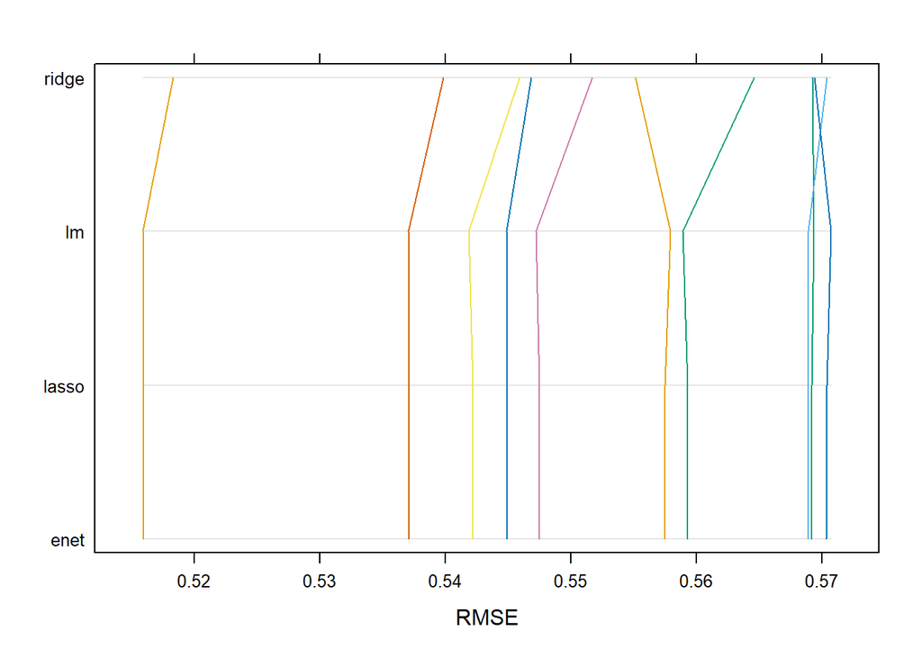

```r
resamp = resamples(list(
  enet = enet_fit,
  lasso = lasso_fit,
  ridge = ridge_fit,
  lm = lm_fit
))

parallelplot(resamp, metric = "RMSE")
```